# Live Session 1: CLT

Matt Farrow

8/23/2020

## Simulator to Demonstrate CLT

### Control Parameters

```r
df <- read.table(here::here("6306", "week 01", "yob2016.txt"),stringsAsFactors = FALSE,header = FALSE,sep = ";")
n1 <- 10 # sample size per sample for 1st distribution
n2 <- 100 # sample size per sample for 2nd distribution (we will compare these distribuions)
simulations <- 1000 #number of samples and thus number of xbars we will generate.
mu <- 0; # mean parameter for use with normal distribuions
sigma <- 1; # standard deviation parameter for use with normal distribuions
```

### Data Holder

```r
xbar_holder1 <- numeric(simulations) # This will hold all the sample means for the first distribution.
xbar_holder2 <- numeric(simulations) # This will hold all the sample means for the second distribution.
```

### Simulate and Store

Generate 1000 samples each of size 10 and find the mean of each sample. Then store each mean in the xbar_holder vector.

```r
for (i in 1:simulations)
{
  sample1 <- rnorm(n1,mean = mu, sd = sigma)
  sample2 <- rnorm(n2,mean = mu, sd = sigma)
  xbar1 <- mean(sample1)
  xbar2 <- mean(sample2)
  xbar_holder1[i] <- xbar1
  xbar_holder2[i] <- xbar2
}
```

### Display the Distribution of Sample Means (plot a histogram of the sample means)

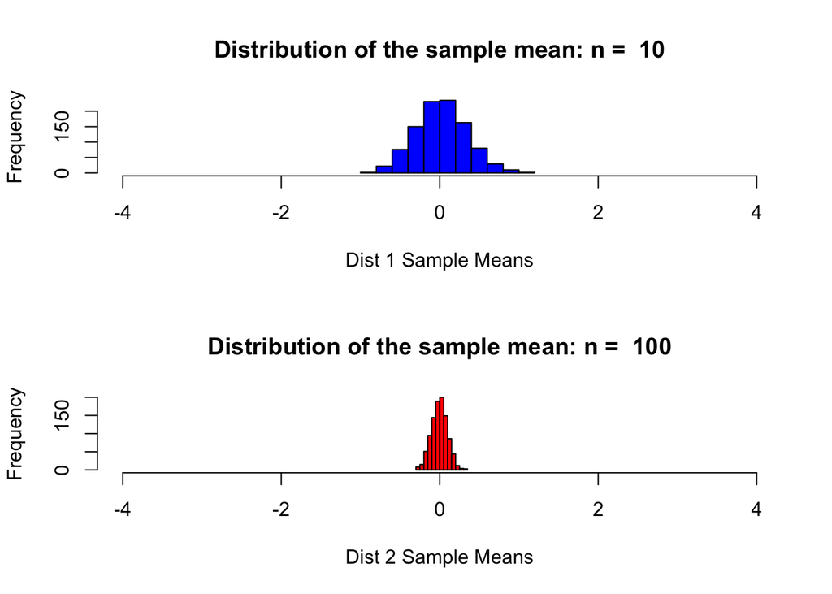

```r
par(mfrow = c(2,1))
hist(xbar_holder1, col = "blue", main = paste("Distribution of the sample mean: n = ", n1), xlab = "Dist 1 Sample Means", xlim = c(-4,4))
hist(xbar_holder2, col = "red", main = paste("Distribution of the sample mean: n = ", n2), xlab = "Dist 2 Sample Means", xlim = c(-4,4))
```

### Summary Statistics of the Distribution of the Simulated Sample Means

```r
summary(xbar_holder1) #5 number summary and the mean
```

```
##     Min.  1st Qu.   Median     Mean  3rd Qu.     Max.
## -0.90514 -0.19931  0.01801  0.02399  0.23448  1.12966
```

```r
summary(xbar_holder2) #5 number summary and the mean
```

```
##       Min.    1st Qu.     Median       Mean    3rd Qu.       Max.
## -0.2977254 -0.0689107 -0.0004015 -0.0016405  0.0633038  0.3243060
```

```r
sd(xbar_holder1) # standard deviation of dstribuion 1
```

```
## [1] 0.3250197
```

```r
sd(xbar_holder2) #standard deviation of distribuion 2
```

```
## [1] 0.1000102
```

## For Live Session

*Adapt the code to generate a population of 10,000,000 from a chi-square distribution with 2 degrees of freedom. This is a heavily right skewed distribution. (Hint: rchisq()). You will have to read up on this function and probably do some trial and error. Being able to learn new functions and methods is a key skill.*

```r
pop <- rchisq(10000000, 2)
```

### Histogram of the Population

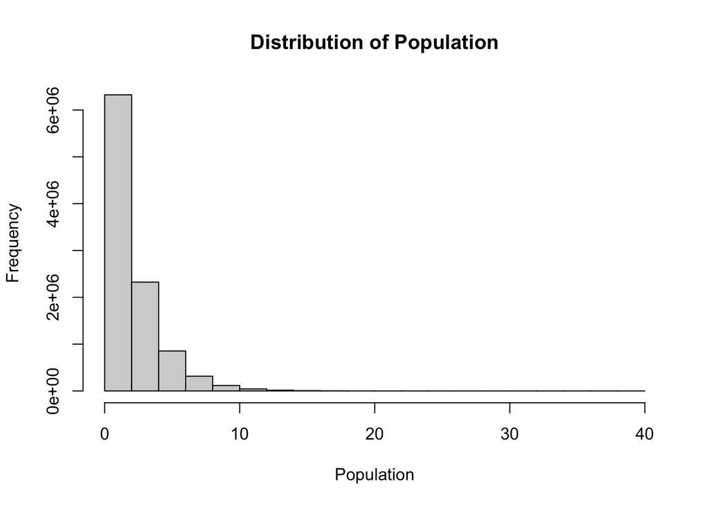

```r
hist(pop, main = "Distribution of Population",
     xlab = "Population",
     ylab = "Frequency")
```

### Mean and Standard Deviation

```r
mean(pop)
```

```
## [1] 1.999486
```

```r
sd(pop)
```

```
## [1] 2.00126
```

### Central Limit Theorem

According to the central limit theorem, what should be the approximate distribution of sample means of size 50 from this right skewed population? **Based on the Central Limit Theorem, the approximate distribution of sample means should be a normal distribution.**

### Setup

```r
# Sample Size
n <- 50

# Number of Samples (and thus number of $\bar{x})$)
simulations <- 10000

# Mean Parameter for Normal Distributions
mu <- 0

# Standard Deviation for Normal Distributions
sigma <- 1

# Data Holder
xbar_holder <- numeric(simulations)
```

### Simulate and Store

Generate 10,000 samples each of size 50 and find the mean of each sample. Then store each mean in the xbar_holder vector.

```r
for (i in 1:simulations)
{
  sample <- rnorm(n,mean = mu, sd = sigma)
  xbar <- mean(sample)
  xbar_holder[i] <- xbar
}
```

### Display the Distribution of Sample Means (plot a histogram of the sample means)

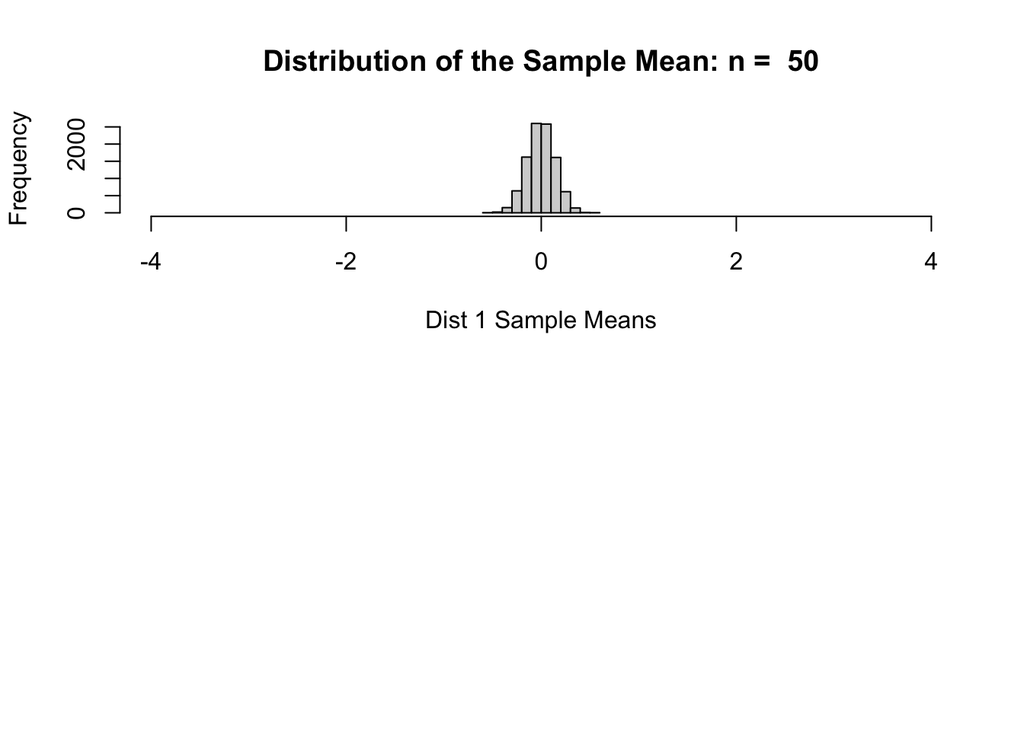

```r
par(mfrow = c(2,1))
hist(xbar_holder,
     main = paste("Distribution of the Sample Mean: n = ", n),
     xlab = "Dist 1 Sample Means", xlim = c(-4,4))
```

### Summary Statistics of the Distribution of the Simulated Sample Means

```r
summary(xbar_holder)
```

```
##      Min.   1st Qu.    Median      Mean   3rd Qu.      Max.
## -0.589013 -0.097323 -0.001055 -0.001695  0.094889  0.551504
```

```r
sd(xbar_holder)
```

```
## [1] 0.1416371
```